# 260677676_Assignment_3_MATH447

#4.19

$$T : = \min\{n : Z_n = 0\}$$
be the extinction time for a branching process.

Show that
$$P(T=n) = G_n(0) - G_{n-1}(0) \ \ n \geq 1$$
We show it by induction.

Base case: We defined $G_0(s) =s$ and $G_1(s) = G(s)$. Assume $Z_0 =1$. It follows that
$$Z_n = \sum_{i=1}^{Z_{n-1}} X_i$$
We obtain
$$Z_1 = X_1$$
and
$$P(T=1) = P(\min{n: Z_n = 0} =1) = P(Z_1 =0) = P(X_1 = 0) = G(0) =$$
$$G(0) - 0 = G_1(0) - G_0(0)$$
Inductive hypothesis: Suppose the claim holds for some $n = 1, ..., k$

Inductive step: We need to show

$$P(T = k+1) = G_{k+1}(0) - G_{k}(0)$$
Remark that
$$P(T \leq k) = \sum_{i=1}^k P(T=i) =$$
By inductive hypothesis, this is a telescoping series:
$$(G_{k}(0) - G_{k-1}(0)) + (G_{k-1}(0) - G_{k-2}(0)) + ... + (G_{1}(0)- G_{0}(0)) =$$
$$G_{k}(0) - G_{0}(0) = G_k(0) - 0 = G_k(0)$$
Remark
$$G_{k+1}(0) = P(Z_{k+1}=0) = P(Z_{k+1}=0, Z_k = 0) + P(Z_{k+1} = 0, Z_k \neq 0) =$$
$$P(Z_k = 0 ) + P(Z_{k+1} = 0, Z_k \neq 0) = G_k(0) + P(T = k+1) \implies$$
$$G_{k+1}(0) - G_{k}(0) = P(T = k+1)$$
So our claim is proved $\square$.

#4.25

Let $T_n = \sum_{i=0}^n Z_i$ be the total number of individuals up to generation n.

$$\phi_n(s) = E[s^{T_n}]$$
be the pgf of $T_n$. ##(a) Show that

$$\phi_n(s) = sG(\phi_{n−1}(s))$$

$$\phi_n(s) = E[s^{T_n}] = E[s^{\sum_{i=0}^n Z_i}]$$
We show it by induction.

Base case: We assume $Z_0 = 1$ We know
$$T_0 = Z_0 = 1$$
implying
$$\phi_0(s) = E[s^1] = sE[1] = s$$

$$\phi_1(s) = E[s^{T_1}] = E[s^{Z_0 + Z_1}] = E[s^{Z_0 + 1}] = E[s s^{Z_0}] = sE[s^{Z_1}] =$$

$$s E[s^{X_1}] = sE[s^X] = sG(s) = sG(\phi_0(s))$$

Inductive hypothesis:

Suppose the recurrence relation holds for $n= 1, ..., k$.

Inductive step:

We need to show that
$$\phi_{k+1}(s) = sG(\phi_{k}(s))$$
We know that
$$\phi_{k+1}(s) = E[s^{T_k + Z_{k+1}}] = E[s * s^{\sum_{i=1}^{k+1} Z_i}] =sE[E[s^{\sum_{i=1}^{k+1} Z_i}|Z_1]] = sE[s^{\sum_{i=1}^{k+1} Z_i}] =$$
$$s(E[s^{\sum_{i=1}^{k+1} Z_i}|Z_1=0]*P(Z_1 = 0) + E[s^{\sum_{i=1}^{k+1} Z_i}|Z_1 > 0]*P(Z_1 > 0) ) =$$
Since if $Z_1 = 0 $ $Z_j = 0 $ for all $j \geq 2$.

$$s(1*P(Z_1=0) +E[s^{\sum_{i=1}^{k+1} Z_i}|Z_1 > 0]*P(Z_1 > 0) ) =$$
$$s(G(0) + \sum_{j=1}^{\infty}E[s^{\sum_{i=1}^{k+1} Z_i}|Z_1 = j]*P(Z_1 = j )) =$$

$$s(\sum_{j=0}^\infty E[s^{\sum_{i=1}^{k+1} Z_i}|Z_1 = j]*P(Z_1 = j))$$
Remark that
$$E[s^{\sum_{i=1}^{k+1} Z_i}|Z_1 = j]$$
is like calculating another total progeny $\tilde{T}_i = T_i - 1$ but now with different number of starting individuals.

4.16(a) states that since starting individuals make offsprings independently with each other

$$E[s^{\sum_{i=1}^{k+1} Z_i}|Z_1 = j] = \phi_k(s)^j$$
It follows that
$$s(\sum_{j=0}^\infty E[s^{\sum_{i=1}^{k+1} Z_i}|Z_1 = j]*P(Z_1 = j)) =$$
$$s(\sum_{j=0}^\infty \phi_k(s)^j*P(Z_1 = j)) = s(\sum_{j=0}^\infty \phi_k(s)^j*P(Z= j)) =$$
$$sE[\phi_k(s)^Z] = sG(\phi_k(s))$$
concluiding the proof.

##(b) If
$$T = \lim_{n \rightarrow \infty} T_n$$
exists we also obtain that $ _{n-1 } T_n = T$ as well. Since pgf is an increasing function on the interval $(0, 1]$

$$\lim_{k \rightarrow \infty} \phi_k(s) = \lim_{k \rightarrow \infty} sG(\phi_{k-1}(s))$$
otherwise limit does not exist. It follows that
$$\phi(s) = sG(\phi(s))$$
##(c)
$$\frac{d \phi}{d s} = \frac{d}{ds} s G(\phi(s)) =$$
$$G(\phi(s)) + s \sum_{j \in \mathbb{N}^+} j \phi(s)^{j-1} \frac{d \phi}{d s} P(X = j) =$$
$$\sum_{ \in \mathbb{N_0}} j \phi(s)^{j}P(X = j) + s \sum_{j \in \mathbb{N}^+} j \phi(s)^{j-1} \frac{d \phi}{d s} P(X = j) =$$
$$\frac{d \phi}{d s}(1-s \sum_{j \in \mathbb{N}^+} j \phi(s)^{j-1} P(X = j)) = \sum_{j \in \mathbb{N_0}} \phi(s)^{j}P(X = j)$$
$$\implies \frac{d \phi}{d s} = \frac{\sum_{j \in \mathbb{N_0}} \phi(s)^{j}P(X = j) }{(1-s \sum_{j \in \mathbb{N}^+} j \phi(s)^{j-1} P(X = j))}$$
It follows that
$$\frac{d \phi}{d s}(1) =\frac{\sum_{j \in \mathbb{N_0}} \phi(1)^{j}P(X = j) }{(1-1 \sum_{j \in \mathbb{N}^+} j \phi(1)^{j-1} P(X = j))} =$$
since $E[1^r] = 1$ for all integer, consequently
$$\frac{\sum_{j \in \mathbb{N_0}} E[1^{T}]P(X = j) }{(1-1 \sum_{j \in \mathbb{N}^+} j E[1^T] P(X = j))} = \frac{\sum_{j \in \mathbb{N_0}} P(X = j) }{(1- \sum_{j \in \mathbb{N}^+} jP(X = j))} =$$
$$\frac{1}{1-\mu}$$
In the subcritical case #4.26

We define our random variable $W$be the count of matching numbers. It is a hypergeometric random variable with parameters $N, K, n$, i.e.
$$W \sim \text{ Hypergeometric}(N=100, K=3, n= 3)$$
with pmf
$$P(W=w) = \frac{{K\choose w}{N-K \choose n-w}}{{N \choose n}}$$
Now, define a function that maps count of matching numbers to the amount you will be winning
$$h: \{0, 1, 2, 3\} \rightarrow \mathbb{R}$$
defined as below:
$$h: \begin{cases} 0 & \mapsto & -1 \\ 1 & \mapsto & 2 \\ 2 & \mapsto & 14 \\ 3 & \mapsto & 999 \end{cases}$$
##(a) Then we are finding $E_X[h(X)]$

```r
v <- c(-1*((choose(97, 3))/(choose(100, 3))), 2*((3*choose(97, 2))/(choose(100, 3))),14*(3*97/(choose(100, 3))), 999/(choose(100, 3)))
sum(v)
```

```
## [1] -0.7076747
```

which is about 70.8 cents.

##(b) In case of parlaying we have the offspring distribution
$$a = (a_0, 0, 0 , a_3, 0, 0, ..., 0, a_{15})$$
where every component besides $a_0$, $a_3$ and $a_15$ is zero.

Naturally
$$a_3 = P(W=1) = \frac{{3\choose 1}{97\choose2}}{{100\choose3}}$$
and
$$a_{15} = P(W=2) = \frac{{3\choose2}{97\choose 1}}{{100\choose3}}$$
$a_0$ consists of two cases : firstly where you got none of the matchiong numbers correctly, and secondly where you hit the jackpot. Thus we have
$$a_0 = P(W=0) + P(W=3) = \frac{{97\choose3}+1}{{100\choose 3}}$$
. For the mean we will have

$$\mu =0.286141 < 1$$
Thus the process is subcritical

```r
a <- c(((choose(97, 3))/(choose(100, 3))), ((3*choose(97, 2))/(choose(100, 3))),(3*97/(choose(100, 3))), 1/(choose(100, 3)))
k <- c(0, 3, 15, 0)
mu <- sum(a*k)
mu
```

```
## [1] 0.286141
```

##(c) If T denotes the duration of the process, the probability $P(T=k)$ for $k = 1, ..., 4$ would be

$$P(T=n) = G_n(0) - G_{n-1}(0)$$

Proved from 4.19.

First, let’s define some functions in R:

```r
G<- function(s){
#mgf for offpsring distribution
    a <- c(((choose(97, 3)+1)/(choose(100, 3))), ((3*choose(97, 2))/(choose(100, 3))),(3*97/(choose(100, 3))))

  v <- c(1, s^3, s^15)

  return(sum(v*a))
}

G_n <- function(n, s){
#composing G(s)
  if(n==0){
    return(s)
  } else{
    return(G_n(n-1, G(s)))
  }
}

T_n = function(n){
#implementing G_n(s) - G_{n-1}(s)
  return((G_n(n,0)-G_n(n-1, 0)))

}
#print(G)
#print(G_n)
#print(T_n)
```

```r
result <- c(0,0,0,0)
for(i in 1:4){
  result[i] = T_n(i)
}
result
```

```
## [1] 0.911818182 0.065936689 0.016092238 0.004409053
```

##(d)

We will first find $p/(1-m)$ since we know $p$ and $m$. We have
$$p = \frac{1}{{100\choose 3}}$$
and
$$\mu =0.286141$$

Thus our asymptotic probability of winning is

```r
p <- 1/choose(100, 3)

p/(1-mu)
```

```
## [1] 8.663184e-06
```

```r
1/(1-mu)
```

```
## [1] 1.400837
```

#5.7 We first construct a block of pseudocode describing Metropolis-Hastings algorithm obtaining a binomial sample from the uniform distribution proposed. We will calculate the acceptance function first. We have
$$\forall k\ \pi_k = {n \choose k} p^k (1-p)^{n-k}$$
And we have
$$T_{kl} = P(T_{1}=l | T_{0} = k) = P(T_1=l) = \frac{1}{n+1}$$
since we independently choose from the discrete uniform distribution that has state space $\{0, ..., n+1\}$

Since $T_{kl}$ is constant for all possible k and l, our acceptance function would be
$$a(i, j) = \min\{1, \frac{\pi_j T_{ji}}{\pi_i T_{ij}}\} = \min\{1, \frac{\pi_j}{\pi_i}\} = \min\{1, \frac{ {n \choose j}}{ {n \choose i} }p^{j-i}(1-p)^{i-j} \}$$
By this we can see $a(i, i) = 1 \ \forall i$

[output not shown]

Let’s implement this into an actual R function.

```r
#5.7
MHbinom <- function(N, n, p){
  simlist <- numeric(N)
  simlist[1] = 0
  for(k in 2:N){
     i = simlist[k-1]
     j = sample(0:n,1)

     acc <- min(1, choose(n, j)/choose(n, i) * p^(j-i)*(1-p)^(i-j))

     if (runif(1)<acc){
       simlist[k] = j
     } else{
       simlist[k] = i
     }

  }

  return(simlist)

}
```

We make a simulation from question #5.8:

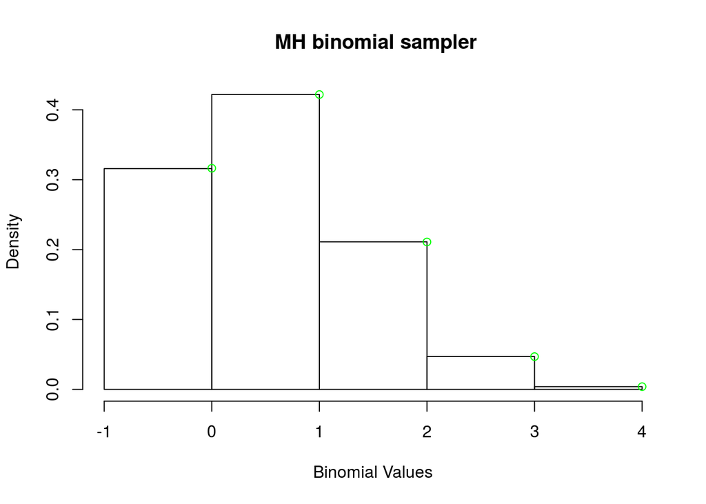

```r
simbinom <- MHbinom(1000000, 4, .25)
hist(simbinom,breaks=seq(-1,4,by=1), xlab="Binomial Values",main=" MH binomial sampler",prob=T)
xref <- seq(0,4,by = 1)
yref <- dbinom(xref,4,.25)
points(xref,yref,col="green")
```

which shows an amazing fit.

We check mean and variance as well.

```r
muCompare = c(1, mean(simbinom))
sigmaCompare = c(4*(0.25)*(0.75), var(simbinom))
muCompare
```

```
## [1] 1.000000 1.001198
```

```r
sigmaCompare
```

```
## [1] 0.7500000 0.7506633
```

# 5.20

We need to obtain a Poisson sample with $\lambda =3$ from a geometric distribution with $p = \frac{1}{3}$ proposed.

We have
$$\forall k\ \pi_k = e^{-\lambda}\frac{\lambda^k}{k!}$$
and
$$\forall i\ j\ T_{ij} = P(X_1 = j | X_0 = i) = P(X_1 = j) = (1-p)^{j-1} p$$
So our acceptance function would be

```r
#5.20
MHPoisson <- function(N, lambda, p){
  # We sample from Poisson random variable with mean lambda
  # We propose geometric distribution with proportion p
  # We use the "time-till-the-first-success" definition of geometric distribution
  # P(X=k; p) = (1-p)^(k-1)p

  simlist <- numeric(N)
  simlist[1] <- 1 # we assume a positive integer state space

  for(k in 2:N){
    i = simlist[k-1]
    j = rgeom(1, p)+1

    acc <- lambda^(j-i)*(factorial(i)/factorial(j))*(1-p)^(i-j)

    if(runif(1) < acc){
      simlist[k] = j

    } else {
      simlist[k] = i
    }

  }
  return(simlist)
}
```

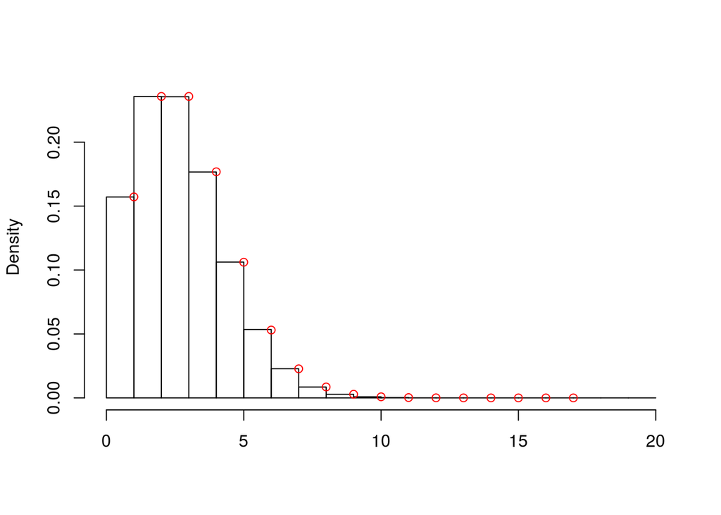

```r
simlistPois <- MHPoisson(1000000, 3, 1/3)

xref <- seq(min(simlistPois), max(simlistPois), by=1)
yref <- dpois(xref,3)/(1-exp(-3))

hist(simlistPois, breaks=seq(0,20,by=1) ,xlab="",main="",freq=F)
points(xref,yref,col="red")
```

It shows a great fit as well.

We also compare mean and variance

```r
#compare mean and variance to 3, the "supposed" value
c(3, mean(simlistPois), var(simlistPois))
```

```
## [1] 3.000000 3.158654 2.663100
```

We can have a decrease in variance since we conditioned our Poisson sample to be nonzero. Besides that, it matches